# Normali komanda - humanMethylation

# 1. Clean up the annotation

# 2. Prepare and save the RGChannelSet

Due to the low quality of previous data, we will be using already prepared raw data objects from Bioconductor experiment package FlowSorted.Blood.450k.

A few samples from the dataset:

```r
# Load data
data <- FlowSorted.Blood.450k
saveRDS(data, file="../../output/step_1/RGSet.RDS")

# Show a few samples information
samples_list <- head(pData(data), 10)
kable(samples_list, "html") %>%
      kable_styling(font_size=10) %>%
      kable_styling("striped") %>%
      scroll_box(width="100%")
```

|  | Sample_Name | Slide | Array | Basename | SampleID | CellTypeLong | CellType | Sex |
| --- | --- | --- | --- | --- | --- | --- | --- | --- |
| WB_105 | WB_105 | 5684819001 | R01C01 | idat/5684819001_R01C01 | 105 | Whole blood | WBC | M |
| WB_218 | WB_218 | 5684819001 | R02C01 | idat/5684819001_R02C01 | 218 | Whole blood | WBC | M |
| WB_261 | WB_261 | 5684819001 | R03C01 | idat/5684819001_R03C01 | 261 | Whole blood | WBC | M |
| PBMC_105 | PBMC_105 | 5684819001 | R04C01 | idat/5684819001_R04C01 | 105 | PBMC | PBMC | M |
| PBMC_218 | PBMC_218 | 5684819001 | R05C01 | idat/5684819001_R05C01 | 218 | PBMC | PBMC | M |
| PBMC_261 | PBMC_261 | 5684819001 | R06C01 | idat/5684819001_R06C01 | 261 | PBMC | PBMC | M |
| Gran_105 | Gran_105 | 5684819001 | R01C02 | idat/5684819001_R01C02 | 105 | Granulocytes | Gran | M |
| Gran_218 | Gran_218 | 5684819001 | R02C02 | idat/5684819001_R02C02 | 218 | Granulocytes | Gran | M |
| Gran_261 | Gran_261 | 5684819001 | R03C02 | idat/5684819001_R03C02 | 261 | Granulocytes | Gran | M |
| CD4+_105 | CD4+_105 | 5684819001 | R04C02 | idat/5684819001_R04C02 | 105 | CD4+ T-cells | CD4T | M |

```r
# Remove redundant variables
rm(samples_list)
```

# 3. Obtain detection p-values

All values with detection p-value > 0.01 are considered as “bad”. As we can see from the following code, there are no samples that have more than 1% of “bad” values. Therefore, no samples have been removed in this step.

The graph below shows the first 10 samples p-value percentage. Small values indicate that the dataset is of a high quality.

```r
# Obtain detection p-values
detP <- detectionP(data)

# All values with detection p-value > 0.01 are "bad"
failed <- detP > 0.01

# Good sample = fraction of failed positions < 0.01
goodSamples <- colMeans(failed) < 0.01
badSamples  <- colMeans(failed) >= 0.01

# Count good and bad samples
count(goodSamples)
```

```
## [1] 60
```

```r
count(badSamples)
```

```
## [1] 0
```

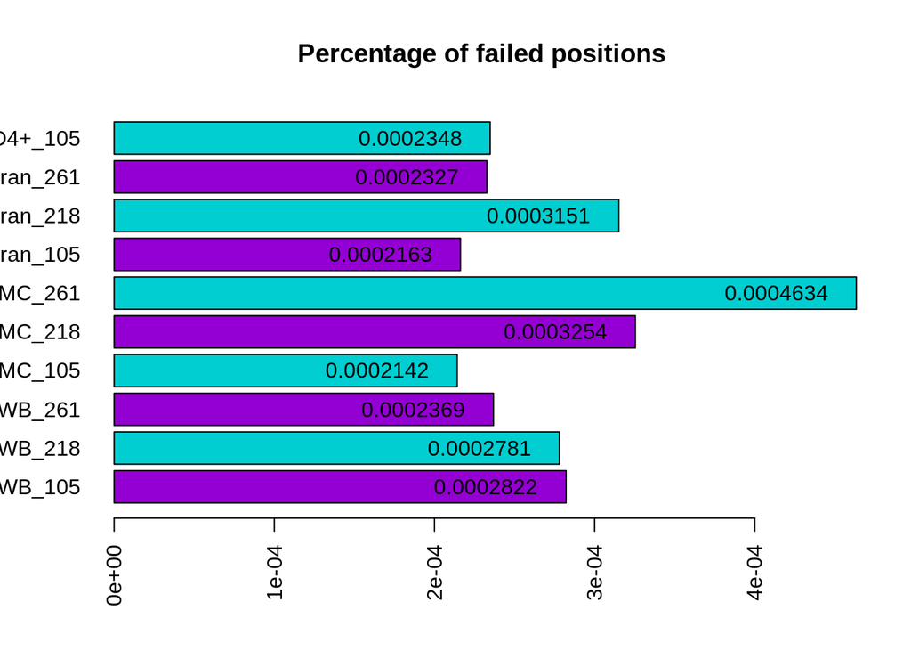

```r
# Barplot showing first 10 samples p-value percentage
randomSamples <- head(colMeans(failed), 10)

b <- barplot(
  horiz=TRUE,
  randomSamples,
  las=2,
  col=c("darkviolet", "darkturquoise"),
  main="Percentage of failed positions"
)

text(
  y=b,
  x=randomSamples-0.00005,
  labels=as.character(format(round(randomSamples, 7), nsmall = 2))
)
```

```r
# Remove redundant variables
rm(b)
rm(goodSamples)
rm(badSamples)
rm(randomSamples)
```

# 4. Normalize the dataset

```r
data <- preprocessSWAN(data)
```

# 5. Remove all probes that have more than 1% of “bad” detection p-values

```r
# Remove all probes that are "bad"
goodProbes <- rowMeans(failed) < 0.01
data <- data[goodProbes, ]

# Remove redundant variables
rm(failed)
rm(goodProbes)
```

# 6. Remove “CH” probes and “SNP related” probes

```r
data <- dropMethylationLoci(data)
```

# 7. Extract the 3 tables from the prepared object file

```r
# The main matrix of values
dataMatrix <- getBeta(data)

# The sample key information
keyInfo <- pData(data)

# The meta information about rows
metaInfo <- getAnnotation(data)
```

# 8. Implement the IAC outlier removal method

The first three graphs represent the original dataset without outlier removal. We’ve chosen sdout = -2 and performed two iterations to eliminate outliers. The following graphs represent the quality increase with each iteration.

```r
# Calculating IACs for all pairs of samples and
# examining the distribution of IACs in the dataset
dim(dataMatrix)
```

```
## [1] 481158     60
```

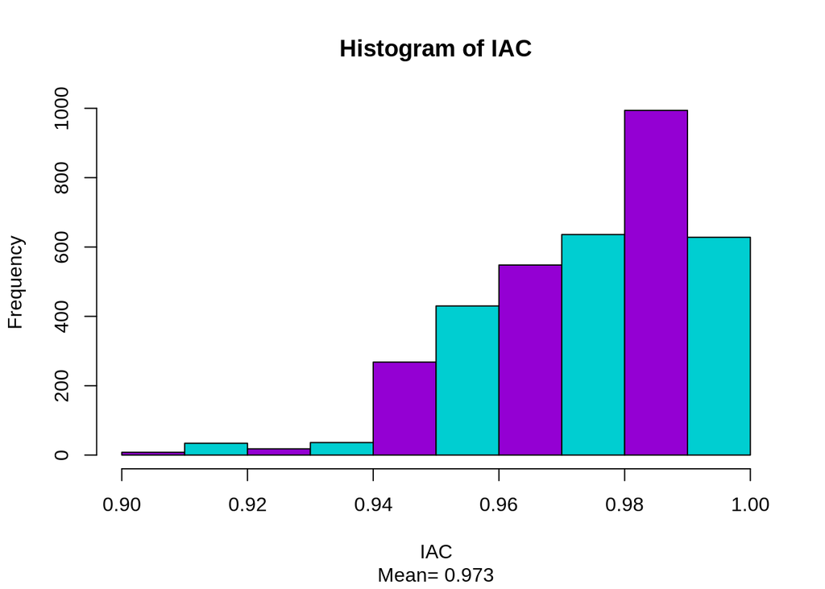

```r
IAC <- cor(dataMatrix, use="p")
hist(
  IAC,
  sub=paste("Mean=", format(mean(IAC[upper.tri(IAC)]), digits=3)),
  col=c("darkviolet", "darkturquoise")
)
```

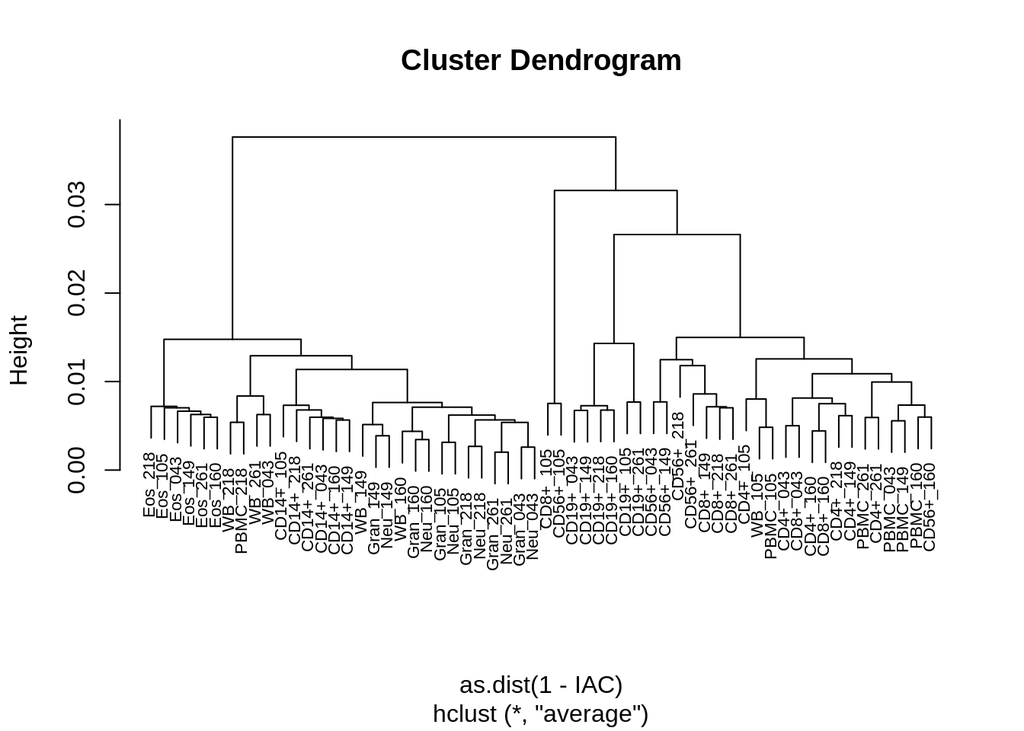

```r
# Performing hierachical clustering using 1-IAC as a distance metric
cluster <- hclust(as.dist(1-IAC), method="average")
plot(
  cluster,
  cex=0.7,
  labels=dimnames(dataMatrix)[[2]]
)
```

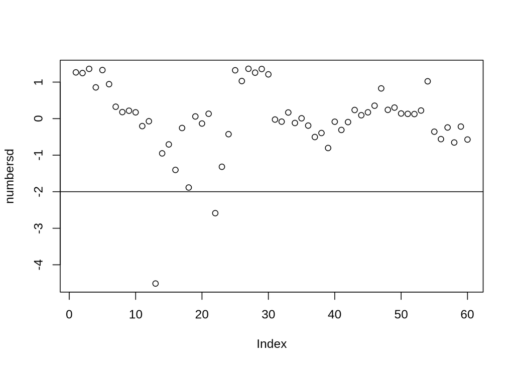

```r
# Another way to visualize outliers
# Calculating the mean IAC for each array
meanIAC <- apply(IAC, 2, mean)
sdCorr <- sd(meanIAC)
numbersd <- (meanIAC-mean(meanIAC))/sdCorr
plot(numbersd)
abline(h=-2)
```

```r
# Outliers depicted above are the
# same outliers identified in the initial dendrogram
sdout <- -2
outliers <- dimnames(dataMatrix)[[2]][numbersd<sdout]
outliers
```

```
## [1] "CD8+_105"  "CD56+_105"
```

```r
# Removing outliers and calculating new IAC matrix
dataMatrix2 <- dataMatrix[, numbersd>sdout]
dim(dataMatrix2)
```

```
## [1] 481158     58
```

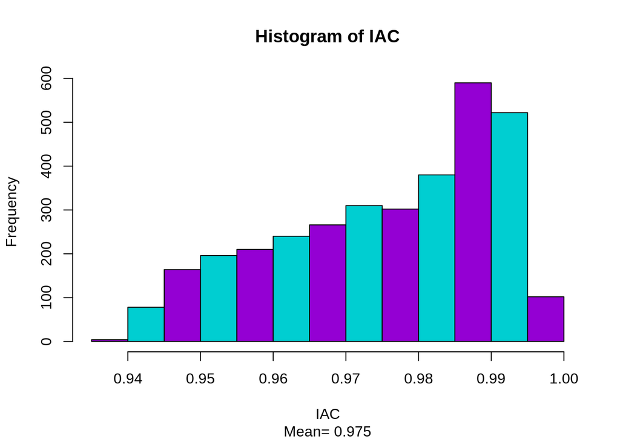

```r
###
IAC <- cor(dataMatrix2, use="p")
hist(
  IAC,
  sub=paste("Mean=", format(mean(IAC[upper.tri(IAC)]), digits=3)),
  col=c("darkviolet", "darkturquoise")
)
```

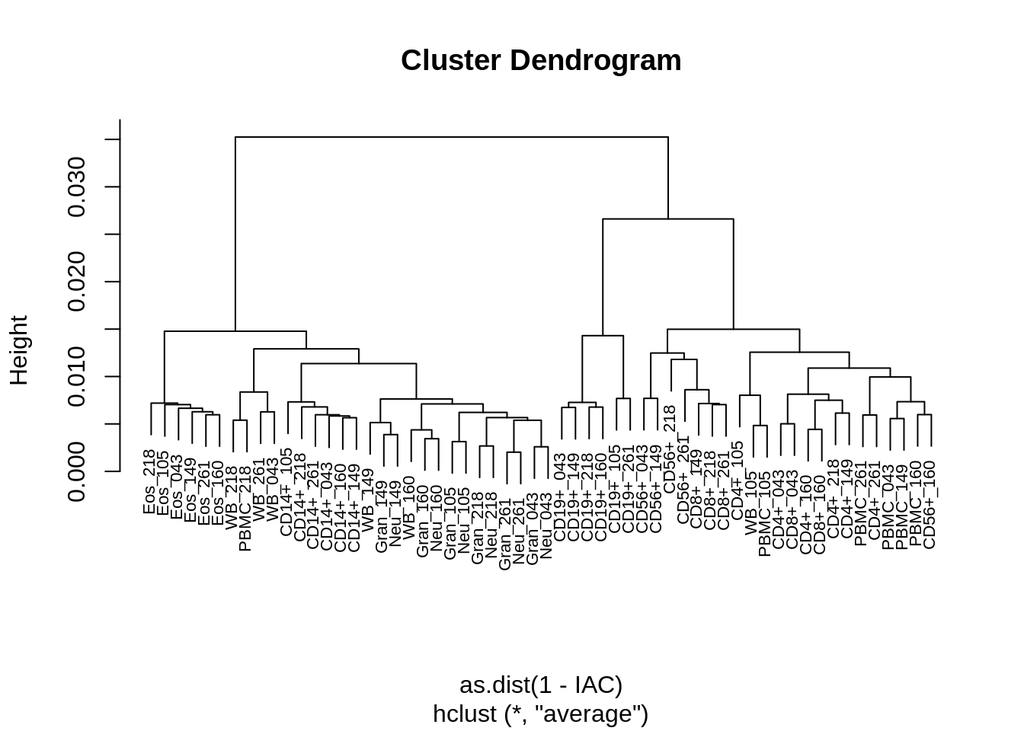

```r
###
cluster <- hclust(as.dist(1-IAC), method="average")
plot(
  cluster,
  cex=0.7,
  labels=dimnames(dataMatrix2)[[2]]
)
```

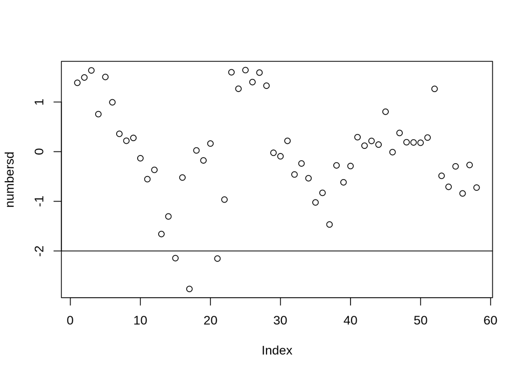

```r
###
meanIAC <- apply(IAC, 2, mean)
sdCorr <- sd(meanIAC)
numbersd <- (meanIAC-mean(meanIAC))/sdCorr
plot(numbersd)
abline(h=-2)
```

```r
# Repeating the same process again
sdout <- -2
outliers <- dimnames(dataMatrix2)[[2]][numbersd<sdout]
outliers
```

```
## [1] "CD19+_105" "CD19+_261" "CD56+_218"
```

```r
###
dataMatrix3 <- dataMatrix2[, numbersd>sdout]
dim(dataMatrix3)
```

```
## [1] 481158     55
```

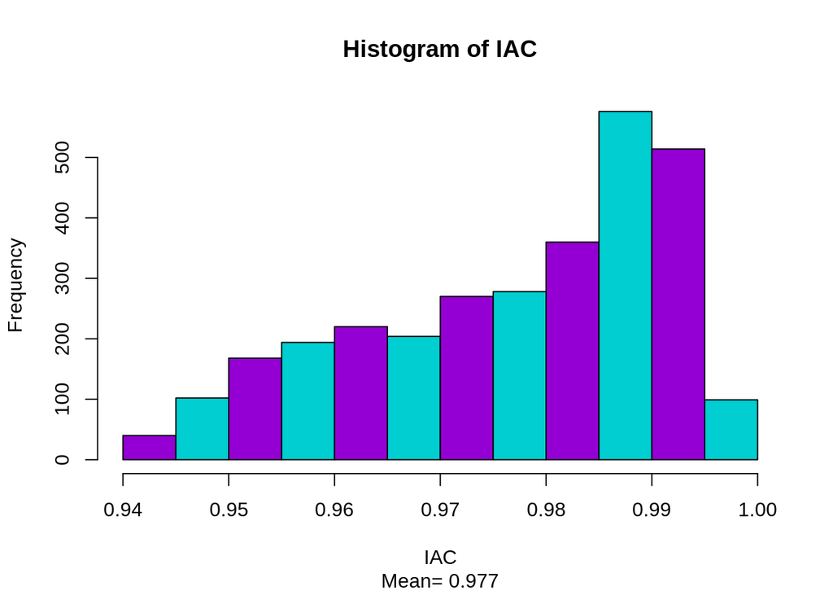

```r
###
IAC <- cor(dataMatrix3, use="p")
hist(
  IAC,
  sub=paste("Mean=", format(mean(IAC[upper.tri(IAC)]), digits=3)),
  col=c("darkviolet", "darkturquoise")
)
```

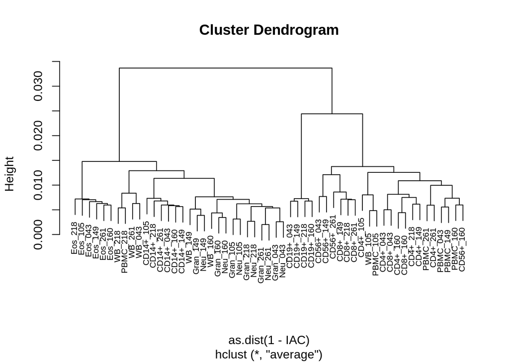

```r
###
cluster <- hclust(as.dist(1-IAC), method="average")
plot(
  cluster,
  cex=0.7,
  labels=dimnames(dataMatrix3)[[2]]
)
```

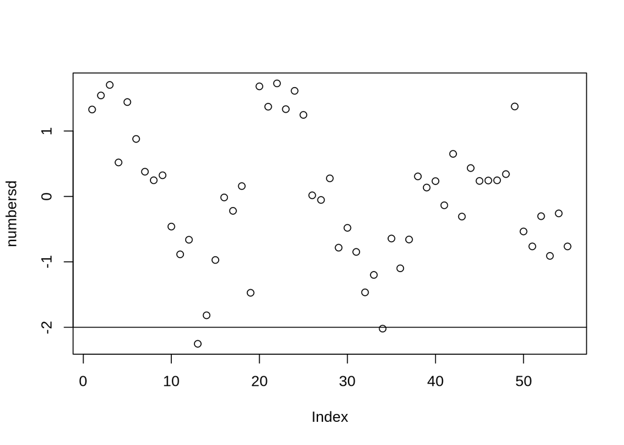

```r
###
meanIAC <- apply(IAC, 2, mean)
sdCorr <- sd(meanIAC)
numbersd <- (meanIAC-mean(meanIAC))/sdCorr
plot(numbersd)
abline(h=-2)
```

```r
###
dataMatrix <- dataMatrix3

# Removing redundant variables
rm(IAC)
rm(cluster)
rm(dataMatrix2)
rm(dataMatrix3)
rm(outliers)
rm(meanIAC)
rm(sdCorr)
rm(numbersd)
rm(sdout)
```

# 9. Add a short quality control step

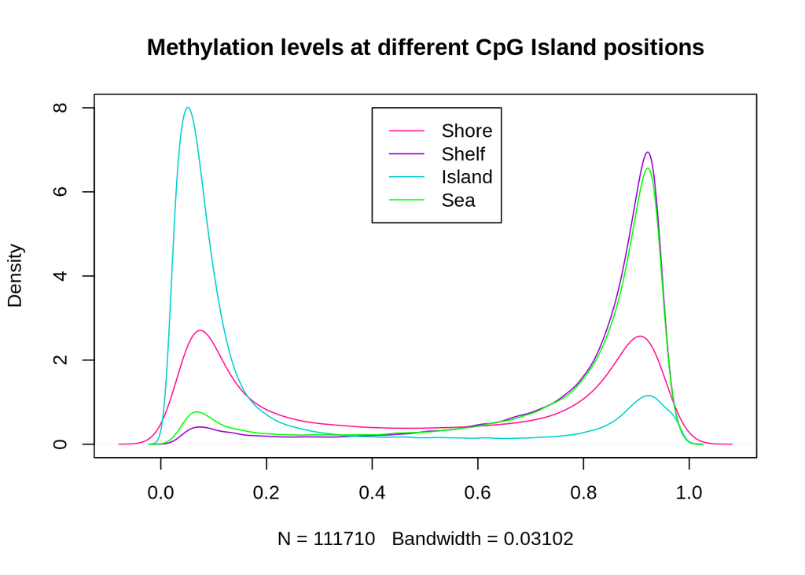

```r
# Comparing methylation levels at different CpG Island positions
cpgMeans <- rowMeans(dataMatrix)

names(cpgMeans) <- metaInfo$Relation_to_Island

shore   <- cpgMeans[names(cpgMeans) %in% c("N_Shore", "S_Shore")]
shelf   <- cpgMeans[names(cpgMeans) %in% c("N_Shelf", "S_Shelf")]
island  <- cpgMeans[names(cpgMeans) == "Island"]
sea     <- cpgMeans[names(cpgMeans) == "OpenSea"]

plot(
  density(shore),
  ylim=c(0,8),
  col="deeppink",
  main="Methylation levels at different CpG Island positions",
  cex=2
)

lines(density(shelf), col="darkviolet", cex=2)
lines(density(island), col="darkturquoise", cex=2)
lines(density(sea), col="green", cex=2)

legend(
  x=0.4,
  y=8,
  legend=c("Shore", "Shelf", "Island", "Sea"),
  col=c("deeppink", "darkviolet", "darkturquoise", "green"),
  lty=1
)
```

```r
# Remove redundant variables
rm(cpgMeans)
rm(island)
rm(sea)
rm(shelf)
rm(shore)
```

# 10. Save the prepared data objects to the output directory

```r
saveRDS(data, "../../output/step_1/finalData.RDS")
saveRDS(dataMatrix, "../../output/step_1/dataMatrix.RDS")
saveRDS(keyInfo, "../../output/step_1/keyInfo.RDS")
saveRDS(metaInfo, "../../output/step_1/metaInfo.RDS")
```